# Bias correction methods for test-negative design in the presence of misclassification

Akira Endo, Sebastian Funk, Adam J. Kucharski

## Simulation of the bias correction method for univariate analysis

We investigate the accuracy of the univariate bias correction method given in the main text. Mean total sample size ($\frac{1+\gamma\delta}{1+\delta}\lambda_V +\lambda_U$) was set to be 3,000. A range of scenarios are employed (See Table 1 in the main text), and the true vaccine effectiveness $\gamma$ was compared with the estimates from the simulated data. For each scenario, 500 sets of data were generated repeatedly.

```r
# parameter preparation
mean_size <- 3000  # mean sample size of TND
n_sim <- 500  # number of simulations

parms1 <- cbind(expand.grid(VE = c(0.4, 0.8), LR = 0.5, CR = 0.5, sens = c(0.8,
    0.95, 0.6)), spec = rep(c(0.95, 0.97, 0.9), each = 2))
parms2 <- expand.grid(VE = c(0.4, 0.8), LR = 0.5, CR = c(0.7, 0.3), sens = 0.8,
    spec = 0.95)
parms3 <- expand.grid(VE = c(0.4, 0.8), LR = c(0.7, 0.3), CR = 0.5, sens = 0.8,
    spec = 0.95)
parms <- rbind(parms1, parms2, parms3)  # parameter combinations for simulation scnearios
titles <- paste0(rep(c("Baseline", paste(c("High", "Low"), rep(c("quality test",
    "TD incidence", "vaccine coverage"), each = 2))), each = 2), c(": low VE",
    ": high VE"))  # Figure titles
oddsratio <- function(data_table) {
    prod(diag(data_table))/data_table[1, 2]/data_table[2, 1]
}  # returns odds ratio given a 2-by-2 table
```

```r
# simulation
sim_result1 <- list(nrow(parms))  # store results
for (id in 1:nrow(parms)) {
    parm <- unlist(parms[id, ])
    o_alpha <- (1 - parm["sens"])/parm["sens"]
    o_beta <- (1 - parm["spec"])/parm["spec"]
    true_inc <- c(parm["CR"], 1 - parm["CR"]) %*% t(c(parm["LR"], 1 - parm["LR"]))
    true_inc[1, 1] = true_inc[1, 1] * (1 - parm["VE"])
    true_inc = true_inc * mean_size/sum(true_inc)  # ensure mean sample size = mean_size
    test_mat <- matrix(c(parm["sens"], 1 - parm["sens"], 1 - parm["spec"], parm["spec"]),
        2, 2)

    # corrected/raw estimates from simulated data
    est <- cbind(est_corr = numeric(n_sim), est_raw = numeric(n_sim), est_true = numeric(n_sim))
    for (i in 1:n_sim) {
        set.seed(id + i)
        data_true <- matrix(rpois(4, true_inc), 2, 2)  # simulated true data
        ve_true <- 1 - oddsratio(data_true)
        ## Misclassification
        misdiag_PtoN <- rbinom(2, data_true[1, ], 1 - parm["sens"])
        misdiag_NtoP <- rbinom(2, data_true[2, ], 1 - parm["spec"])
        data_obs <- data_true
        data_obs[1, ] = data_obs[1, ] - misdiag_PtoN + misdiag_NtoP
        data_obs[2, ] = data_obs[2, ] - misdiag_NtoP + misdiag_PtoN

        data_correct <- matrix(c(1, -o_alpha, -o_beta, 1), 2, 2) %*% data_obs  # correction
        data_correct <- matrix(pmax(0, data_correct), 2, 2)  # truncate negative values
        ve_est = 1 - c(oddsratio(data_correct), oddsratio(data_obs))
        est[i, ] = c(ve_est, ve_true)
    }
    sim_result1[[id]] = list(est = est[, 1], raw = est[, 2], true = est[, 3],
        parm = parm)
}
```

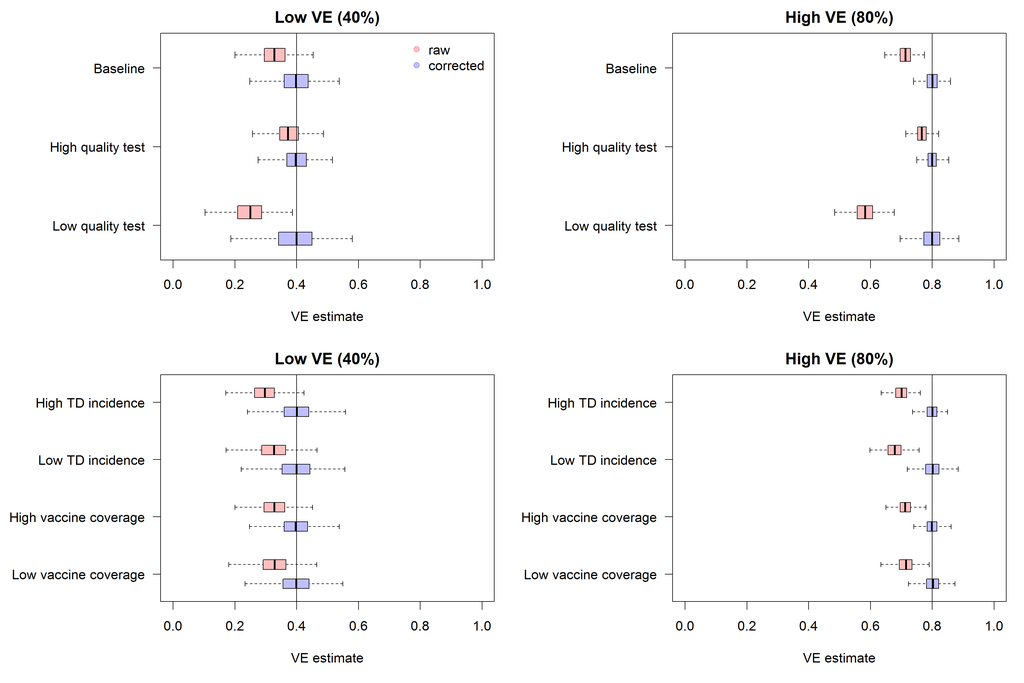

## Simulation of the bias correction method for multivariate analysis

### Parametric bootstrapping

```r
# parameter preparation
mean_size <- 3000  # mean sample size of TND
n_sim <- 500  # number of simulations
n_iter <- 100  # number of iterations for MI
VE_upp <- 1
VE_low <- -0.5  # Upper and lower bounds of VE

parms1 <- cbind(expand.grid(VE = c(0.4, 0.8), LR = 0.5, CR = 0.5, sens = c(0.8,
    0.95, 0.6)), spec = rep(c(0.95, 0.97, 0.9), each = 2))
parms2 <- expand.grid(VE = c(0.4, 0.8), LR = 0.5, CR = c(0.7, 0.3), sens = 0.8,
    spec = 0.95)
parms3 <- expand.grid(VE = c(0.4, 0.8), LR = c(0.7, 0.3), CR = 0.5, sens = 0.8,
    spec = 0.95)
parms <- rbind(parms1, parms2, parms3)  # parameter combinations for simulation scnearios

RR_age <- c(2, 1.5)  #relative risk for age (TD, ND)
pop_age <- c(1, 2)
RR_ab <- c(0.5, 1)  #relative risk for antibody titer (TD, ND)
```

```r
# Simulation & estimation function
msimulator <- function(parm, seed) {
    set.seed(seed)
    VE <- parm["VE"]
    LR <- parm["LR"]
    CR <- parm["CR"]
    sens <- parm["sens"]
    spec <- parm["spec"]

    lambda_vac <- (matrix(c((1 - VE) * CR, 1 - CR, CR, 1 - CR), 2, 2) %*% c(LR,
        1 - LR))
    lambda_age <- (matrix(c(RR_age[1] * CR, RR_age[2] * (1 - CR), CR, 1 - CR),
        2, 2) %*% pop_age)
    lambda_ab <- c(exp(log(RR_ab[1])^2/2) * CR, exp(log(RR_ab[2])^2/2) * (1 -
        CR))
    lambda_true <- lambda_vac * lambda_age * lambda_ab
    lambda_true <- lambda_true/sum(lambda_true) * mean_size

    # Simulation
    S_true <- rpois(2, lambda_true)  # number of TD and ND cases
    ## Covariate sampling
    xi_vac_TD <- sample.int(2, S_true[1], replace = T, prob = rev(c(LR, 1 -
        LR) * c(1 - VE, 1))) - 1
    xi_vac_ND <- sample.int(2, S_true[2], replace = T, prob = rev(c(LR, 1 -
        LR))) - 1
    xi_age_TD <- sample.int(2, S_true[1], replace = T, prob = rev(pop_age *
        c(RR_age[1], 1))) - 1
    xi_age_ND <- sample.int(2, S_true[2], replace = T, prob = rev(pop_age *
        c(RR_age[2], 1))) - 1
    xi_ab_TD <- rnorm(S_true[1], log(RR_ab[1]), 1)
    xi_ab_ND <- rnorm(S_true[2], log(RR_ab[2]), 1)

    xi_TD <- cbind(vac = xi_vac_TD, age = xi_age_TD, ab = xi_ab_TD)
    xi_ND <- cbind(vac = xi_vac_ND, age = xi_age_ND, ab = xi_ab_ND)

    lreg_true <- glm(test ~ ., family = binomial(link = "logit"), data = as.data.frame(rbind(cbind(test = 1,
        xi_TD), cbind(test = 0, xi_ND))))

    ## Misclassification
    sample_pos <- rbinom(2, S_true, c(sens, 1 - spec))  # number of positives who are with TD / ND
    D_pos <- rbind(head(xi_TD, sample_pos[1]), head(xi_ND, sample_pos[2]))
    D_pos <- cbind(test = 1, D_pos)
    D_neg <- rbind(tail(xi_TD, S_true[1] - sample_pos[1]), tail(xi_ND, S_true[2] -
        sample_pos[2]))
    D_neg <- cbind(test = 0, D_neg)

    return(list(D_pos = D_pos, D_neg = D_neg, lreg_true = lreg_true))
}

# Estimation: parametric bootstrapping
est_pb <- function(d_pos, d_neg, n_pos = nrow(d_pos), n_neg = nrow(d_neg), phat = NULL,
    n_iter, parm, seed) {
    set.seed(seed)
    VE <- parm["VE"]
    LR <- parm["LR"]
    CR <- parm["CR"]
    sens <- parm["sens"]
    spec <- parm["spec"]
    ## Prob of flipping the result
    pflip_pos <- (sens * (1 - phat[["pos"]])/phat[["pos"]] - (1 - sens)) * ((1 -
        spec)/(sens + spec - 1))
    pflip_pos <- pmin(1, pmax(0, pflip_pos))
    pflip_neg <- (spec * phat[["neg"]]/(1 - phat[["neg"]]) - (1 - spec)) * ((1 -
        sens)/(sens + spec - 1))
    pflip_neg <- pmin(1, pmax(0, pflip_neg))

    ve_est <- numeric(n_iter)
    for (iter in 1:n_iter) {
        ## Row IDs to be flipped
        idflip_pos <- runif(n_pos) < pflip_pos
        idflip_neg <- runif(n_neg) < pflip_neg
        ## Flip
        copy_d_pos <- d_pos
        copy_d_neg <- d_neg
        copy_d_pos[idflip_pos, "test"] = 0
        copy_d_neg[idflip_neg, "test"] = 1
        data <- as.data.frame(rbind(copy_d_pos, copy_d_neg))

        # Logistic regression on flipped data
        lreg <- glm(test ~ ., family = binomial(link = "logit"), data = data)
        ve_est[iter] <- 1 - exp(lreg[[1]][2])  # Corrected estimate
    }
    return(ve_est)
}

msim_est <- function(parm, seed, method = "pb", ncovs = 1) {
    ## simulate
    if (ncovs == 1)
        simdata <- msimulator(parm = parm, seed = seed) else simdata <- manycov_simulator(parm = parm, seed = seed, ncovs)
    D_pos <- simdata$D_pos
    D_neg <- simdata$D_neg
    ve_true <- 1 - exp(simdata$lreg_true[[1]][2])

    # Estimation from raw data
    lreg_raw <- glm(test ~ ., family = binomial(link = "logit"), data = as.data.frame(rbind(D_pos,
        D_neg)))
    ve_raw <- 1 - exp(lreg_raw[[1]][2])  # raw VE estimate
    # predicted probabilities for bootstrapping
    phat_pos <- predict(lreg_raw, as.data.frame(D_pos), type = "response")
    phat_neg <- predict(lreg_raw, as.data.frame(D_neg), type = "response")

    # Estimation Multiple imputation
    n_pos <- nrow(D_pos)
    n_neg <- nrow(D_neg)

    if (method == "pb") {
        # parametric bootstrap
        MI_est <- est_pb(D_pos, D_neg, n_pos, n_neg, phat = list(pos = phat_pos,
            neg = phat_neg), n_iter, parm, seed = seed)
    } else if (method == "dl") {
        # direct likelihood
        MI_est <- est_dl(D_pos, D_neg, n_pos, n_neg, phat = list(pos = phat_pos,
            neg = phat_neg), n_iter, parm, seed = seed)
    } else if (method == "em") {
        # EM algorithm
        MI_est <- est_em(D_pos, D_neg, n_pos, n_neg, phat = list(pos = phat_pos,
            neg = phat_neg), n_iter, parm, seed = seed)
    } else {
        # without estimation
        MI_est <- NA
    }
    ve_qest <- quantile(MI_est, c(0.5, 0.025, 0.975), na.rm = T)
    ve_qest <- pmin(pmax(ve_qest, VE_low), VE_upp)  # limit VE within bounds
    return(c(ve_qest, ve_true = ve_true, ve_raw = ve_raw))
}
```

```r
# simulation: parametric bootstrap
sim_result2 <- list(nrow(parms))  # store results
for (id in 1:nrow(parms)) {
    parm <- unlist(parms[id, ])

    sims <- suppressWarnings(sapply(1:n_sim + id, msim_est, parm = parm, method = "pb"))
    sim_result2[[id]] = list(est = sims[1, ], CI = sims[2:3, ], true = sims[4,
        ], raw = sims[5, ], parm = parm)
}
```

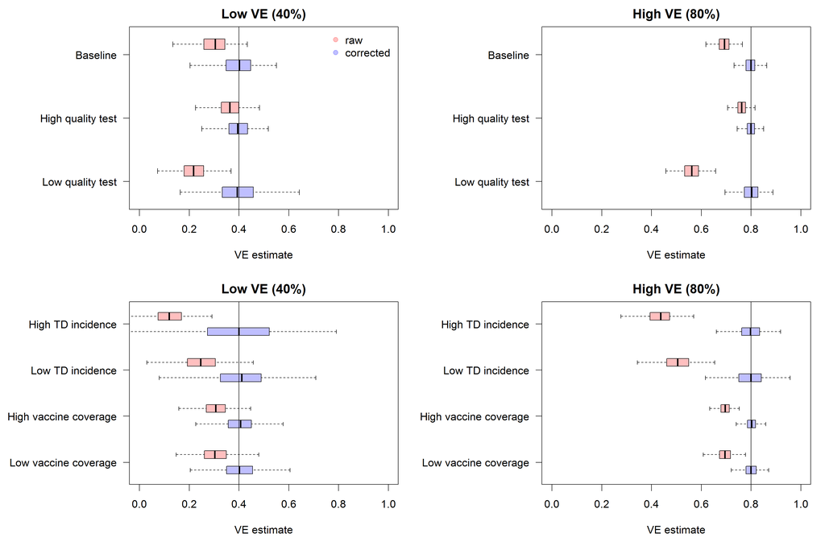

## Comparison of bias correction methods

We compare three methods: the direct likelihood method, parametric bootstrapping and EM algorithm. Simulation settings are identical to those in the previous section. In the EM algorithm, the first 100 iterations out of total 200 are discarded as burn-in.

```r
est_em <- function(d_pos, d_neg, n_pos = nrow(d_pos), n_neg = nrow(d_neg), phat = NULL,
    n_iter, parm, seed = 1) {
    set.seed(seed)
    VE <- parm["VE"]
    LR <- parm["LR"]
    CR <- parm["CR"]
    sens <- parm["sens"]
    spec <- parm["spec"]

    # EM algorithm initialise
    ve_est <- numeric(n_iter)
    phat_pos <- phat[["pos"]]
    phat_neg <- phat[["neg"]]

    for (iter in 1:n_iter) {
        ## Prob of flipping the result
        pflip_pos <- 1 - sens * phat_pos/(sens * phat_pos + (1 - spec) * (1 -
            phat_pos))
        pflip_pos <- pmin(1, pmax(0, pflip_pos))
        pflip_neg <- 1 - spec * (1 - phat_neg)/((1 - sens) * phat_neg + spec *
            (1 - phat_neg))
        pflip_neg <- pmin(1, pmax(0, pflip_neg))

        ## Row IDs to be flipped
        idflip_pos <- runif(n_pos) < pflip_pos
        idflip_neg <- runif(n_neg) < pflip_neg
        ## Flip
        copy_d_pos <- d_pos
        copy_d_neg <- d_neg
        copy_d_pos[idflip_pos, "test"] = 0
        copy_d_neg[idflip_neg, "test"] = 1
        data <- as.data.frame(rbind(copy_d_pos, copy_d_neg))

        # Logistic regression on flipped data
        lreg <- glm(test ~ ., family = binomial(link = "logit"), data = data)
        phat_pos <- predict(lreg, as.data.frame(copy_d_pos), type = "response")
        phat_neg <- predict(lreg, as.data.frame(copy_d_neg), type = "response")

        ve_est[iter] <- 1 - exp(lreg[[1]][2])  # Corrected estimate
    }
    ve_est <- tail(ve_est, n_iter%/%2)
    return(ve_est)
}

est_dl <- function(d_pos, d_neg, n_pos = nrow(d_pos), n_neg = nrow(d_neg), phat = NULL,
    n_iter, parm, seed) {
    set.seed(seed)
    VE <- parm["VE"]
    LR <- parm["LR"]
    CR <- parm["CR"]
    sens <- parm["sens"]
    spec <- parm["spec"]

    # direct likelihood method
    nlogl <- function(theta) {
        # covariates
        cov_pos <- cbind(1, d_pos[, -1])
        cov_neg <- cbind(1, d_neg[, -1])
        # linear predictor
        lp_pos <- cov_pos %*% theta
        lp_neg <- cov_neg %*% theta
        # likelihood computation
        TD_pos <- plogis(lp_pos)
        lik_pos <- sens * TD_pos + (1 - spec) * (1 - TD_pos)
        ND_neg <- plogis(-lp_neg)
        lik_neg <- spec * ND_neg + (1 - sens) * (1 - ND_neg)
        return(-(sum(log(lik_pos)) + sum(log(lik_neg))))
    }
    fit <- optim(par = numeric(ncol(d_pos)) + 0.1, fn = nlogl, method = "L-BFGS")  #,upper = 1-VE_low ,lower=1-VE_upp)
    ve_est <- 1 - exp(fit$par[2])
    return(ve_est)
}
```

```r
n_iter = 200
# simulation: parametric bootstrap
sim_result3 <- list(nrow(parms))  # store results
for (id in 1:nrow(parms)) {
    parm <- unlist(parms[id, ])

    sim_dl <- suppressWarnings(sapply(1:n_sim + id, msim_est, parm = parm, method = c("dl")))
    sim_em <- suppressWarnings(sapply(1:n_sim + id, msim_est, parm = parm, method = c("em")))

    sim_result3[[id]] = lapply(list(sim_dl, sim_em), function(sim) {
        return(list(est = sim[1, ], CI = sim[2:3, ], true = sim[4, ], raw = sim[5,
            ], parm = parm))
    })
}
```

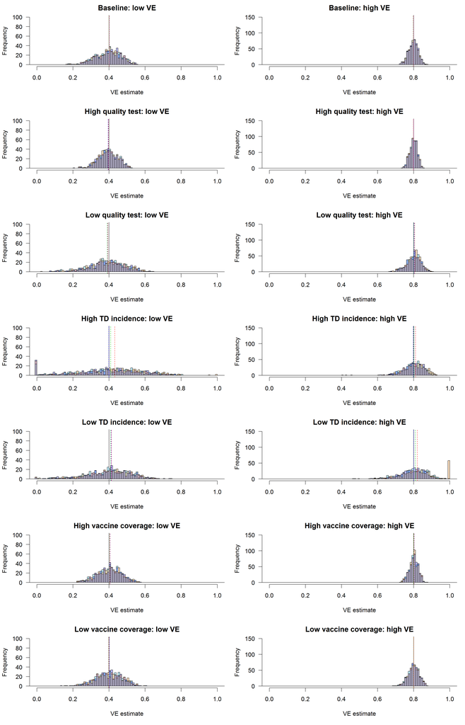